[figure not shown]

Control estadístico de procesos

Especificaciones y capacidad

Jordi Cuadros, Lucinio González

Octubre de 2018

# Especificaciones

## ¿Qué son las especificaciones?

**Especificación**

Información proporcionada por el fabricante de un producto, la cual describe sus componentes, características y funcionamiento. A menudo constituye el compromiso con el cliente.

- Características
  - Atributos: conformidad
  - Variables: valor dentro de unos límites (LIE, LSE)
- Las especificaciones no estan especificadas por el proceso productivo ni se determinan estadísticamente.

## ¿Cómo se relacionan con el proceso productivo?

- La probabilidad con la que se cumplirán unas especificaciones depende de las características del proceso.
  - Valor central
  - Variabilidad natural
- Distintos procesos productivos pueden tolerar distintos niveles de no conformidad.

## El concepto de capacidad

La capacidad del proceso es la aptitud que tiene éste para producir dentro del intervalo fijado por las especificaciones.

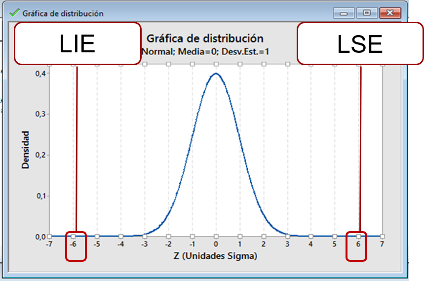

Para realizar un estudio de capacidad de un proceso, se ha de cumplir las siguientes condiciones:

- El proceso debe estar bajo control estadístico, es decir media y variabilidad estable a lo largo del tiempo.
- Los datos deben seguir una distribución normal.
- La muestra debe ser representativa (materiales de partida, ajustes de máquina, cambio de operarios, condiciones ambientales, desgaste…).

En estas condiciones, se puede usar la distribución normal para establecer la capacidad del proceso y relacionar

- las características del mismo (valor central y variabilidad natural), con
- las especificaciones (valor nominal, límite inferior/superior de la especificación).

A partir de la misma puede también determinarse la probabilidad de obtener unidades no conformes con una determinada especificación.

# Distribución normal

## Definición

La **distribución normal** es una distribución teórica simétrica comúnmente usada para la modelización matemática de valores afectados de error aleatorio.

[figure not shown]

https://commons.wikimedia.org/wiki/File:Standard_deviation_diagram_micro.svg

## Ejemplos

Sea un proceso productivo en el que se fabrican láminas de acero. Se ha establecido que la dureza promedio de las piezas producidas es 316 HB y la desviación estándar de las mismas es 25 HB.

Asumiendo que esta variable sigue una distribución normal, determina:

- ¿Qué proporción de piezas tienen un dureza inferior a 250 HB? ¿Y una superior a 350 HB?
- Si se establecen una especificaciones de 320 ± 40 HB, ¿qué proporción de piezas quedarán fuera de especificaciones?
- ¿Qué valor de dureza corresponde es superior al del 95 % de las piezas producidas?

## Inferencia sobre la normalidad

Para contrastar la hipótesis de si un conjunto de datos sigue una distribución normal se usan distintas pruebas y técnicas estadísticas:

- Prueba de Shapiro-Wilk
- Prueba de Anderson-Darling
- Gráfico cuantil-cuantil (QQ) o gráfico de normalidad